Robert Orr

2018-06-04

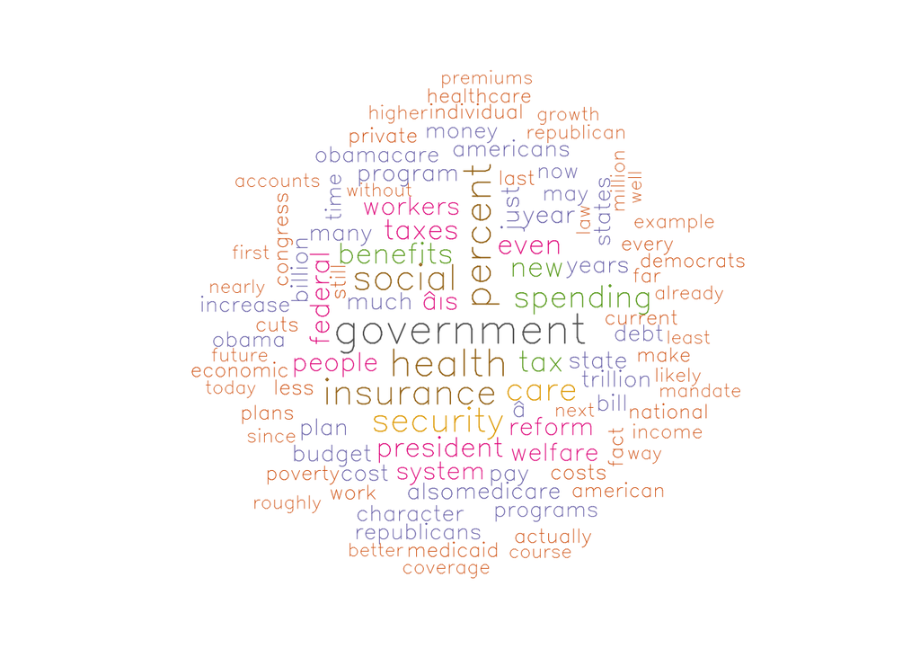

This is Michael D. Tanner’s web analytics report from between the dates 2015-05-01 and 2018-05-17.

**Total unique viewers by day (with top content on highly traffic days highlighted)**

Colored by topic between the dates 2015-05-01 and 2018-05-17.

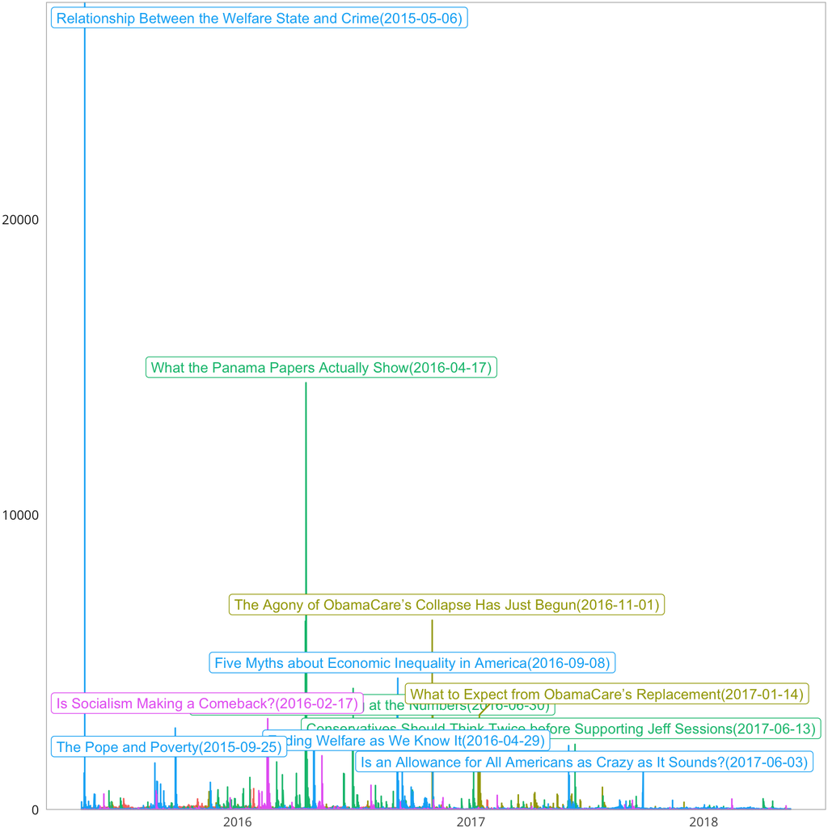

**Popular Co-Authors for Michael D. Tanner (Multimedia Excluded)**

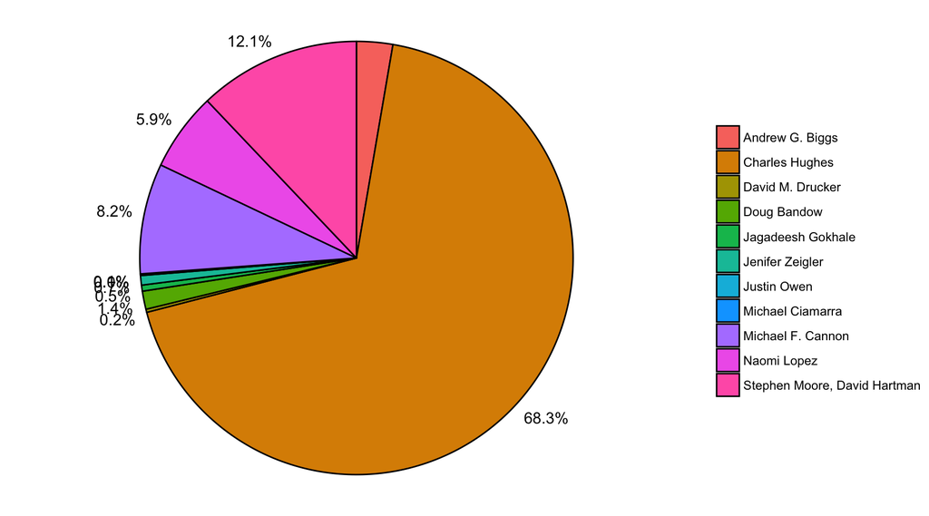

**Count of published content by Michael D. Tanner, colored by co-authorship**

Simple count of authored and co-authored content over course of Cato career.

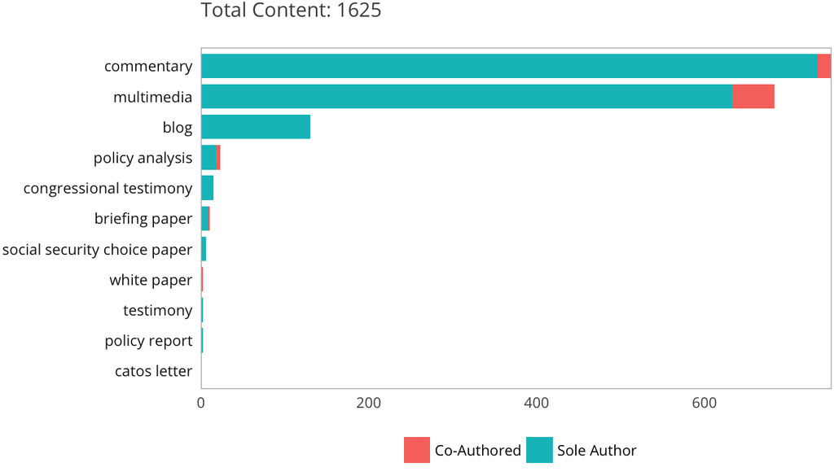

**Unique Users by Media Type Over Reference Period**

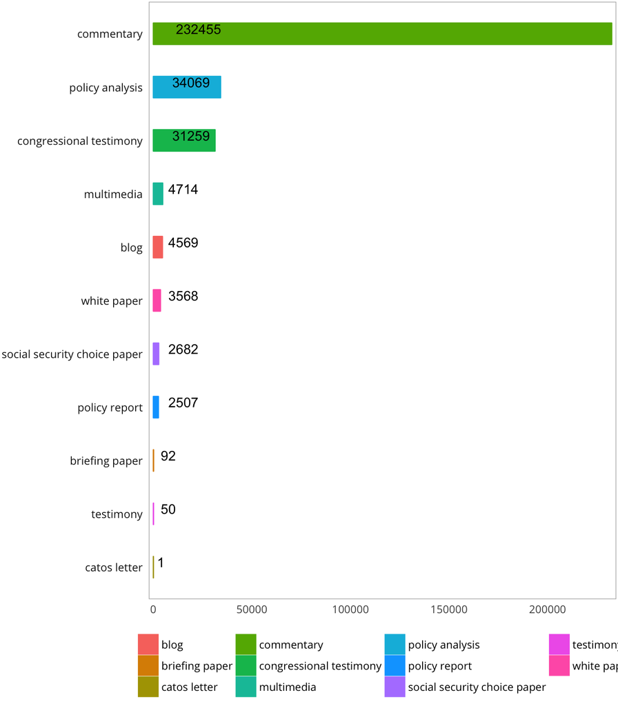

**Unique Users by Subject Type Over Reference Period**

Unique User Visits - Includes all forms of media including podcasts.

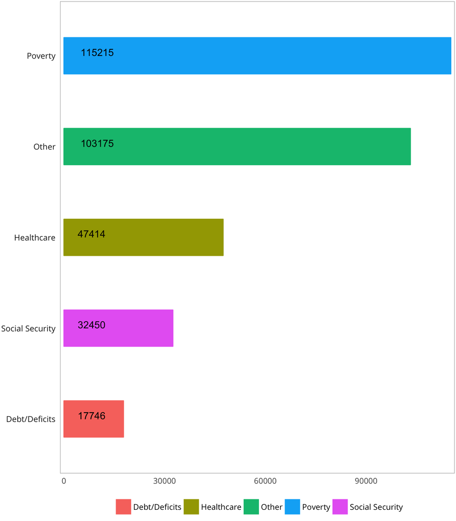

**Top performing content within first 45 Days of Publication**

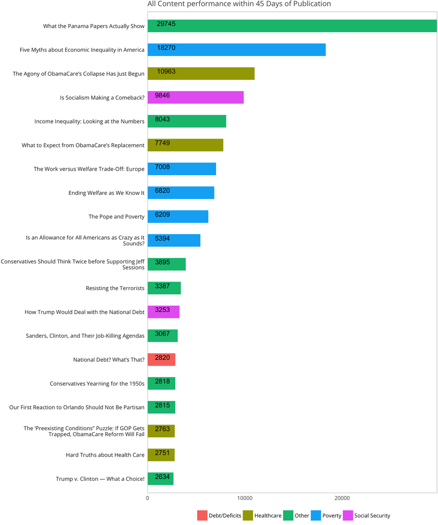

**Unique users for content published within reference (2015-05-01 and 2018-05-17)**

Unique users within reference (2015-05-01 and 2018-05-17)

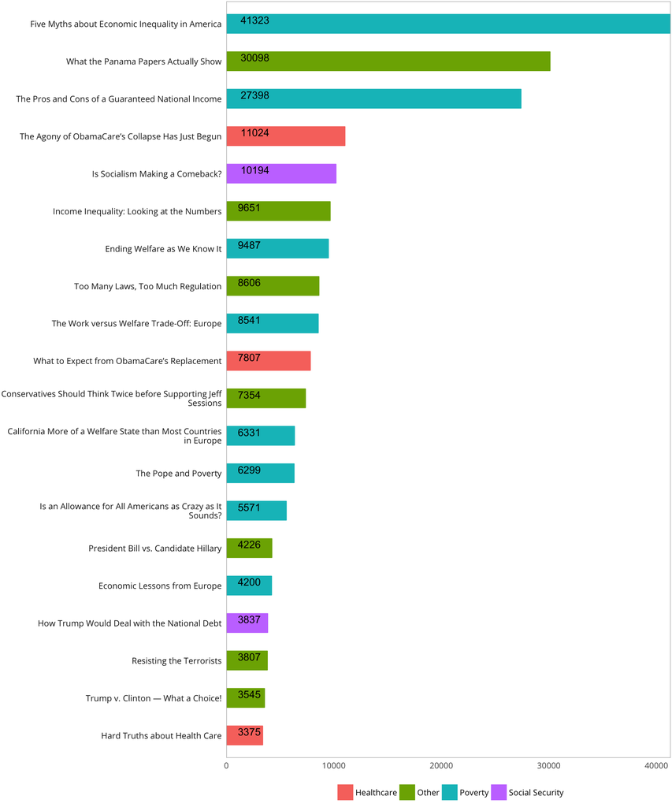

**Older content performance**

Unique users of content *published prior* to the reference period (between 2015-05-01 and 2018-05-17) These pieces continued to attract users despite not being published with the observed period.

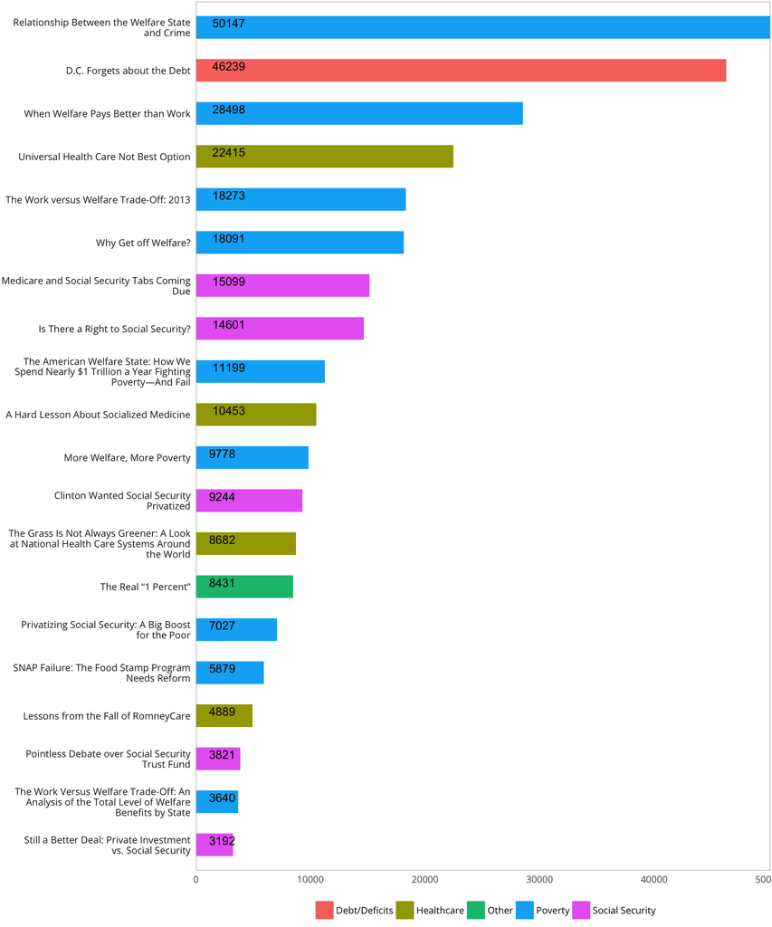

This section examines time spent on reading an article relative to the number of words of text in the article. Below are the 10 best and worst performing articles. Multimedia (e.g. Podcasts) are ignored. This measure is designed to give you a rough idea of the types of articles people are likely to read through.

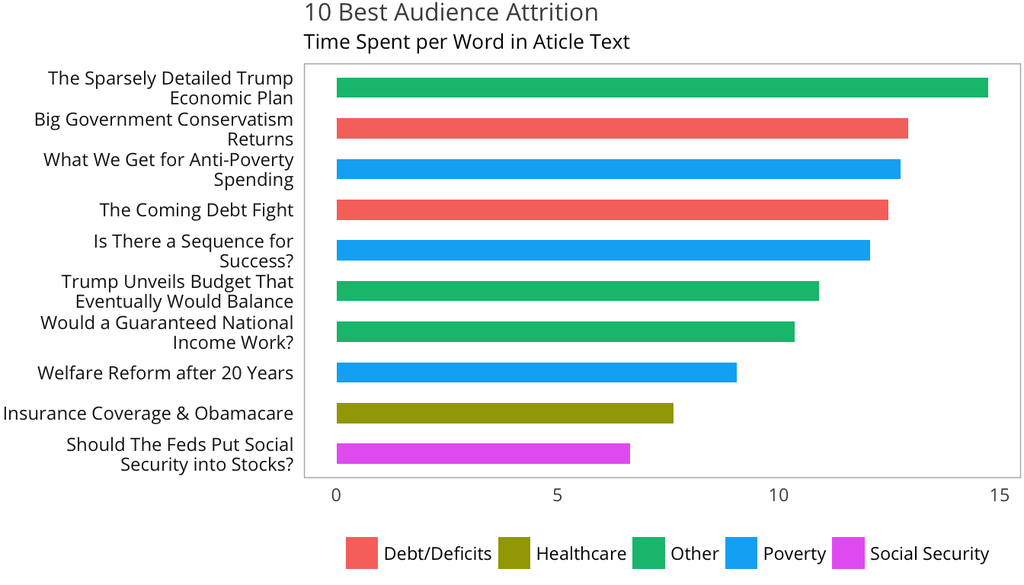

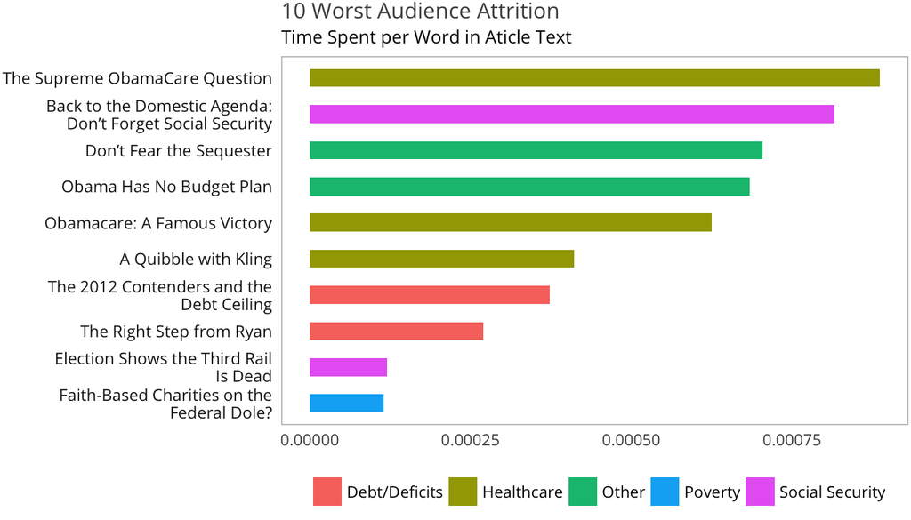

Multimedia content (e.g. Podcasts) has a consistently lower exit rate ascross all authors. The likely explanation for why this is the case has to with the fact that links to other Cato web-content are prominently displayed for media. This insight strongly suggests that links to related content ought to be similarly placed in other forms content (blogs, commentary, policy analyses, etc.)

The webstaff could increase Cato readership by adding a “Suggested Reading” banner with links to related articles.

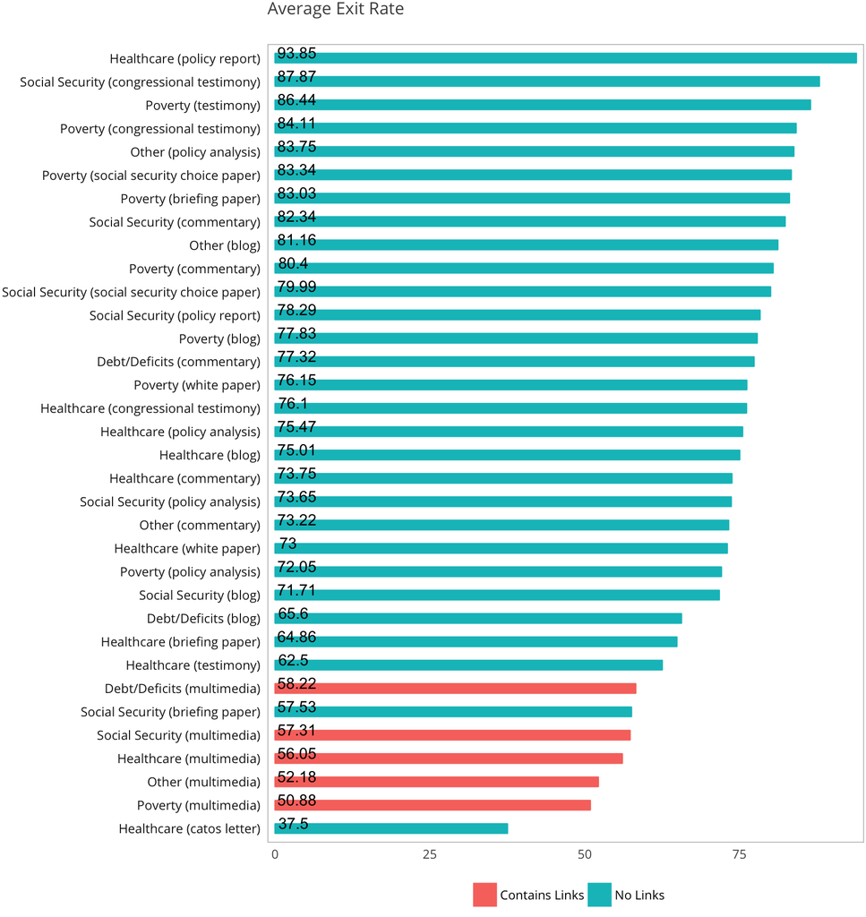

More to come on this..

1. Include relative performances measure to Cato and/or department averages.
2. Integrate Twitter Data. Identify effective Twitter behavior. Offer comparisons between subject of report and other Cato employees.
3. Utilize email list can be associated with the Google Analytics data to demonstrate “influencer interest”. This could be done either on an individual basis (specific email addresses) or using the email domain (@tx.gov, @senate.gov, @GMU.edu, @brookings.org, etc).
4. Other ideas….